# Análise de Preços de Diamantes

Paulo

2025-11-20

## Introdução

Este relatório realiza uma análise exploratória da base `P2-Mispriced-Diamonds.csv`, utilizando gráficos de dispersão e categorização por `clarity`. O arquivo pode ser baixado diretamente do Google Drive ou acessado via unidade mapeada no Windows.

## Configuração do ambiente

## Fonte dos Dados

- Origem: Os dados utilizados neste projeto foram obtidos do conjunto Diamonds disponível no Kaggle: [Conjunto de dados Diamonds no Kaggle.](https://www.kaggle.com/datasets/shivam2503/diamonds)
- Status: Público / Fictício
- Este relatório utiliza a base `P2-Mispriced-Diamonds.csv`.
- Para reproduzir a análise, baixe o arquivo aqui:

🔗 [Download do CSV] [Baixar a base de dados.](https://drive.google.com/file/d/1chAw_lIO47i78vPLyBsRFDPTW-ZECSHC/view?usp=sharing)

## Instalação e carregamento de pacotes

```r
# Instalar e carregar pacotes necessários
pkgs <- c("ggplot2", "data.table", "googledrive")
to_install <- pkgs[!pkgs %in% installed.packages()[, "Package"]]
if (length(to_install)) install.packages(to_install)
invisible(lapply(pkgs, library, character.only = TRUE))
```

## Autenticação no Google Drive (automática)

```r
library(googledrive)

# Verifica se já existe um token ativo
if (is.null(drive_token())) {
  message("Nenhum token encontrado. Autenticando no Google Drive...")
  drive_auth(scopes = "https://www.googleapis.com/auth/drive")
} else {
  message("Já autenticado no Google Drive. Seguindo normalmente...")
}
```

## Leitura e inspeção dos dados

```r
library(data.table)

# Caminho direto para o arquivo no Google Drive mapeado
# Você lê direto da pasta do google drive, via o teu explorador de arquivos (no meu caso: windows)
# Baixar arquivo devido extensão ".csv" (Se google sheet, já conecta "direto" no link).
mydata <- "G:/Meu Drive/R/Analise-Preco-Diamantes/Pasta-Arquivo-Projeto/P2-Mispriced-Diamonds.csv"
```

## Leitura e inspeção dos dados

```r
# Carregar os dados
mydata <- fread("P2-Mispriced-Diamonds.csv")

# Inspeção
mydata
```

```
##        carat clarity price
##        <num>  <char> <int>
##     1:  0.23     SI2   326
##     2:  0.21     SI1   326
##     3:  0.23     VS1   327
##     4:  0.29     VS2   334
##     5:  0.31     SI2   335
##    ---
## 53935:  0.72     SI1  2757
## 53936:  0.72     SI1  2757
## 53937:  0.72     SI1  2757
## 53938:  0.70     SI1  2757
## 53939:  0.86     SI2  2757
```

```r
str(mydata)
```

```
## Classes 'data.table' and 'data.frame':   53939 obs. of  3 variables:
##  $ carat  : num  0.23 0.21 0.23 0.29 0.31 0.24 0.24 0.26 0.22 0.23 ...
##  $ clarity: chr  "SI2" "SI1" "VS1" "VS2" ...
##  $ price  : int  326 326 327 334 335 336 336 337 337 338 ...
##  - attr(*, ".internal.selfref")=<externalptr>
```

```r
dim(mydata)
```

```
## [1] 53939     3
```

```r
summary(mydata)
```

```
##      carat          clarity              price
##  Min.   :0.2000   Length:53939       Min.   :  326
##  1st Qu.:0.4000   Class :character   1st Qu.:  950
##  Median :0.7000   Mode  :character   Median : 2401
##  Mean   :0.7979                      Mean   : 3933
##  3rd Qu.:1.0400                      3rd Qu.: 5324
##  Max.   :5.0100                      Max.   :18823
```

```r
table(mydata$clarity)
```

```
##
##    I1    IF   SI1   SI2   VS1   VS2  VVS1  VVS2
##   741  1790 13065  9193  8171 12258  3655  5066
```

```r
# Remover o arquivo se quiser limpar o diretório
# file.remove("P2-Mispriced-Diamonds.csv")
```

## Gráfico de dispersão: carat vs price

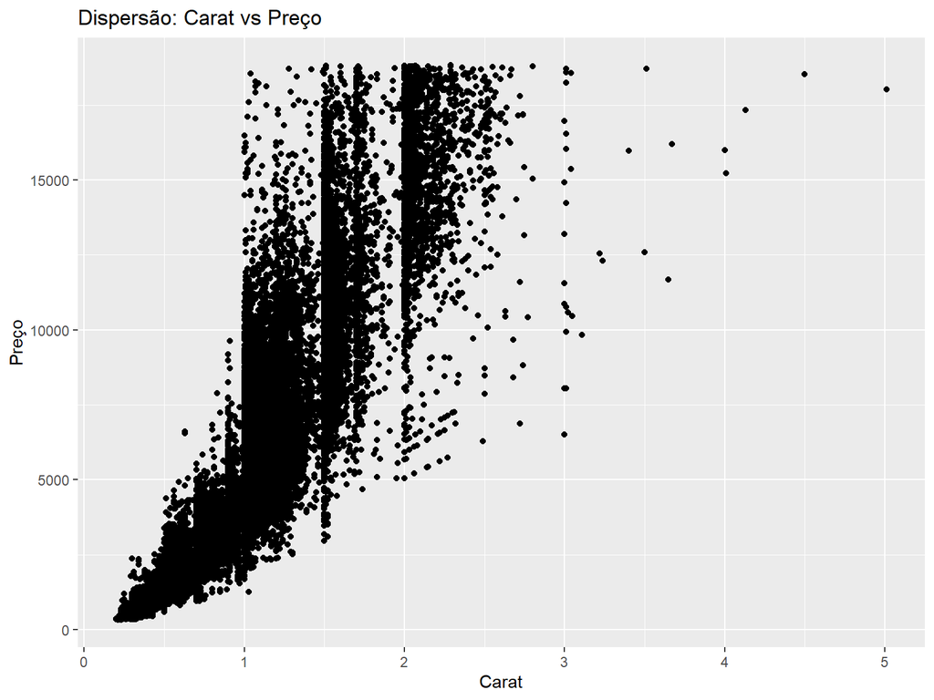

```r
ggplot(data = mydata, aes(x = carat, y = price)) +
  geom_point() +
  labs(title = "Dispersão: Carat vs Preço", x = "Carat", y = "Preço")
```